# Enrichment analysis - Phenotypes

## Initialization

We start the analysis by initializing the packages required for all the analysis performed in this section. We also define the root directory, within which all the input/output operations for this project will be performed. At the end of this document, detailed software version information is provided for easier reproducibility of the analysis.

```r
library(hypeR)
library(reshape2)
library(pheatmap)
library(RColorBrewer)
library(dynamicTreeCut)
library(DT)

path = "/Users/ashwin/Documents/Projects/YeastScreen/Essential_DAmP_screen/"

normDat = readRDS(paste0(path, "data/workspaces/YeastRedox_DAmP_RobustZ_NormalizedData.RDS"))
# normDat =
# readRDS(paste0(path,'data/workspaces/YeastRedox_DAmP_PlateControl_NormalizedData.RDS'))
normDat = normDat$redox_table
genesets = readRDS(paste0(path, "data/workspaces/YeastGeneSets.RDS"))
```

## Hypergeometric test

Here we write a simple hypergeometric test function to perform enrichment analysis. This function is based on the explainations provided on these three sources [1](http://pedagogix-tagc.univ-mrs.fr/courses/ASG1/practicals/go_statistics_td/go_statistics_td_2015.html), [2](http://marray.economia.unimi.it/2007/material/day4/Lecture7.pdf) and [3](http://mengnote.blogspot.com/2012/12/calculate-correct-hypergeometric-p.html)

```r
computeEnrichment = function(gset, genes, fdr_cutoff = 1, pval_cutoff = 1, sort_output = TRUE) {
    # removing possible duplicated entries
    gset = lapply(gset, unique)
    genes = unique(genes)

    # constructing the background population of genes having at least one functional
    # annotation
    univ = unique(unlist(gset))

    # from the selection of genes, considering only those having at least one
    # functional annotation
    genes = genes[genes %in% univ]

    # size of background population - i.e total number of genes with at least one
    # functional annotation
    N = length(univ)

    # size of selection - total number of genes in our selection subset
    k = length(genes)

    # total number of genes in the functional group/pathway
    m = sapply(gset, length)

    # total number of genes NOT in the functional group/pathway
    n = N - m

    # total number of the selected genes in the functional group/pathway
    x = sapply(gset, function(y) sum(genes %in% y))

    # compiling final result
    res = data.frame(matrix(ncol = 6, nrow = length(gset)), stringsAsFactors = F)
    colnames(res) = c("pathway", "pval", "fdr", "foldEnrich", "overlapPercent", "overlapGenes")

    res$pathway = names(gset)
    res$pval = signif(phyper(q = x - 1, m = m, n = n, k = k, lower.tail = FALSE),
        2)
    res$fdr = signif(p.adjust(res$pval, method = "fdr"), 2)
    res$foldEnrich = round(c((x/k)/(m/N)), 2)
    res$overlapPercent = round(c(x/m * 100), 2)
    res$overlapGenes = sapply(gset, function(x) paste(x[x %in% genes], collapse = "|"))

    # selection of significant hits
    res = res[res$pval <= pval_cutoff, ]
    res = res[res$fdr <= fdr_cutoff, ]

    # sort results
    if (sort_output) {
        res = res[order(res$foldEnrich, decreasing = T), ]
    }

    # delete variables
    rm(N, k, m, n, x, univ, genes, gset)

    # return function output
    return(res)
}
```

## Enrichment analysis of top hits

Next we check the enrichment of the -

- mutants having the top and lowest 5% of roGFP2 ratios in cytoplasm with carbon source as glucose, galactose and glycerol
- mutants having the top and lowest 5% of roGFP2 ratios in mitochondria with carbon source as glucose, galactose and glycerol

across Phenotype pathways

```r
# Cytoplasm
cyto = normDat[normDat$Organelle == "Cytoplasm", ]
cyto = split(cyto, cyto$Nutrient)

cytoOX = lapply(cyto, function(x) {
    genes = x$Genes
    vals = x$Median_roGFP2_ratio
    qt.top = quantile(vals, 0.95)
    selgenes = unique(genes[vals > qt.top])

    x = computeEnrichment(gset = genesets$Phenotype, genes = selgenes)

    # Exactly same as in hypeR package For sanity check of my own implemented
    # function !!

    # x = hypeR(signature = selgenes[selgenes %in%
    # unique(unlist(genesets$Phenotype))], gsets = genesets$Phenotype, test =
    # 'hypergeometric', bg = unique(unlist(genesets$Phenotype)), pval_cutoff = 0.05,
    # fdr_cutoff = 0.25, verbose = T)$data

    return(x)
})

cytoRX = lapply(cyto, function(x) {
    genes = x$Genes
    vals = x$Median_roGFP2_ratio
    qt.low = quantile(vals, 0.05)
    selgenes = unique(genes[vals < qt.low])

    x = computeEnrichment(gset = genesets$Phenotype, genes = selgenes)

    return(x)
})

# Mitochondria
mito = normDat[normDat$Organelle == "Mitochondria", ]
mito = split(mito, mito$Nutrient)

mitoOX = lapply(mito, function(x) {
    genes = x$Genes
    vals = x$Median_roGFP2_ratio
    qt.top = quantile(vals, 0.95)
    selgenes = unique(genes[vals > qt.top])

    x = computeEnrichment(gset = genesets$Phenotype, genes = selgenes)

    return(x)
})

mitoRX = lapply(mito, function(x) {
    genes = x$Genes
    vals = x$Median_roGFP2_ratio
    qt.low = quantile(vals, 0.05)
    selgenes = unique(genes[vals < qt.low])

    x = computeEnrichment(gset = genesets$Phenotype, genes = selgenes)

    return(x)
})

rm(cyto, mito)
```

We construct a table containing the enrichment analysis results across all organelle and nutrient conditions.

```r
combo_enrichmat = rbind(cbind(cytoOX$Glucose, Organelle = "Cytoplasm", Nutrient = "Glucose", roGFP2 = "High"),
                        cbind(cytoOX$Galactose, Organelle = "Cytoplasm", Nutrient = "Galactose", roGFP2 = "High"),
                        cbind(cytoOX$Glycerol, Organelle = "Cytoplasm", Nutrient = "Glycerol", roGFP2 = "High"),

                        cbind(mitoOX$Glucose, Organelle = "Mitochondria", Nutrient = "Glucose", roGFP2 = "High"),
                        cbind(mitoOX$Galactose, Organelle = "Mitochondria", Nutrient = "Galactose", roGFP2 = "High"),
                        cbind(mitoOX$Glycerol, Organelle = "Mitochondria", Nutrient = "Glycerol", roGFP2 = "High"),

                        cbind(cytoRX$Glucose, Organelle = "Cytoplasm", Nutrient = "Glucose", roGFP2 = "Low"),
                        cbind(cytoRX$Galactose, Organelle = "Cytoplasm", Nutrient = "Galactose", roGFP2 = "Low"),
                        cbind(cytoRX$Glycerol, Organelle = "Cytoplasm", Nutrient = "Glycerol", roGFP2 = "Low"),

                        cbind(mitoRX$Glucose, Organelle = "Mitochondria", Nutrient = "Glucose", roGFP2 = "Low"),
                        cbind(mitoRX$Galactose, Organelle = "Mitochondria", Nutrient = "Galactose", roGFP2 = "Low"),
                        cbind(mitoRX$Glycerol, Organelle = "Mitochondria", Nutrient = "Glycerol", roGFP2 = "Low")
                      )

combo_enrichmat = combo_enrichmat[,c(1:5,7,8,9,6)]

datatable(combo_enrichmat, rownames = FALSE,
          filter = 'top', class='compact',
          extensions = c('Buttons') ,
          options = list( autoWidth = TRUE,
                          dom = 'Bfrtip',
                          buttons = c('csv', 'excel', 'print')
                         )) %>% formatStyle("pathway","white-space"="nowrap")
```

| pathway | pval | fdr | foldEnrich | overlapPercent | Organelle | Nutrient | roGFP2 | overlapGenes |
| --- | --- | --- | --- | --- | --- | --- | --- | --- |
| nutrient uptake: absent | 0.031 | 1 | 31.96 | 20 | Cytoplasm | Glucose | High | VHT1 |
| cell cycle progression in metaphase: arrested | 0.049 | 1 | 19.98 | 12.5 | Cytoplasm | Glucose | High | SCM3 |
| cell size: normal | 0.049 | 1 | 19.98 | 12.5 | Cytoplasm | Glucose | High | CDC1 |
| RNA accumulation: normal | 0.0049 | 0.61 | 18.8 | 11.76 | Cytoplasm | Glucose | High | UTP13\|UTP14 |
| budding: absent | 0.061 | 1 | 15.98 | 10 | Cytoplasm | Glucose | High | CDC1 |
| RNA accumulation: absent | 0.0081 | 0.61 | 14.53 | 9.09 | Cytoplasm | Glucose | High | UTP13\|UTP14 |
| nuclear import: decreased | 0.1 | 1 | 9.4 | 5.88 | Cytoplasm | Glucose | High | RNA1 |
| cell cycle progression through the G2/M phase transition: arrested | 0.024 | 1 | 8.2 | 5.13 | Cytoplasm | Glucose | High | SCM3\|CEF1 |
| cell cycle progression in G1 phase: arrested | 0.006 | 0.61 | 7.99 | 5 | Cytoplasm | Glucose | High | UTP13\|UTP14\|IPI3 |
| protein/peptide distribution: decreased | 0.12 | 1 | 7.99 | 5 | Cytoplasm | Glucose | High | ERG26 |

[output cut: 4178 more lines]

## Visualization of enrichment analysis

We plot the following heatmaps highlighting -

- A binary matrix of the enrichment p values (fdr pvalue < 0.25 = 1 and fdr pvalue > 0.25 = 0) across all carbon sources and organelles is created. (clustering of rows by binary distance)

All clustering is done by `ward.D2` method. We used the Hybrid Adaptive Tree Cutting of dendrograms provided in [dynamicTreeCut package](https://cran.r-project.org/web/packages/dynamicTreeCut/index.html) to identify optimal number of clusters. The associated paper describing the method can be found [here](https://www.ncbi.nlm.nih.gov/pubmed/18024473). Below is the heatmap showing the enrichment fdr p values (shown in purple hues, darker color corresponds to lower pvalue, fdr pvalue > 0.25 is shown in white).

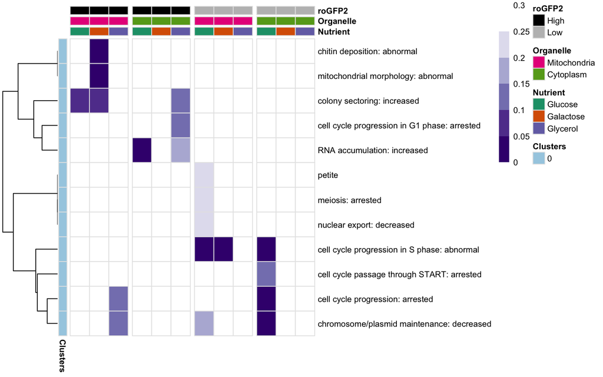

```r
# Creating a common matrix with all the enrichment pvalues
# Rows are pathways, columns are all combinations of nutrient, organelle and roGFP2 states

redoxEnrichMat = dcast(pathway ~ Nutrient + Organelle + roGFP2,
                       data = combo_enrichmat[, c(1, 3, 6:8)],
                       value.var = "fdr")
rownames(redoxEnrichMat) = redoxEnrichMat$pathway
redoxEnrichMat = redoxEnrichMat[, -1]

col_order = c(
  "Glucose_Mitochondria_High",
  "Galactose_Mitochondria_High",
  "Glycerol_Mitochondria_High",
  "Glucose_Cytoplasm_High",
  "Galactose_Cytoplasm_High",
  "Glycerol_Cytoplasm_High",
  "Glucose_Mitochondria_Low",
  "Galactose_Mitochondria_Low",
  "Glycerol_Mitochondria_Low",
  "Glucose_Cytoplasm_Low",
  "Galactose_Cytoplasm_Low",
  "Glycerol_Cytoplasm_Low"
)

redoxEnrichMat = redoxEnrichMat[, match(col_order, colnames(redoxEnrichMat))]
rm(col_order)

# Setting all FDR > 0.25 to NA and removing rows with all NA values
redoxEnrichMat[redoxEnrichMat > 0.25] = NA
na_cnt = apply(redoxEnrichMat, 1, function(x) {
  sum(is.na(x))
})
redoxEnrichMat = redoxEnrichMat[na_cnt < 12,]

# Performing a binary clustering on the rows of the enrichment matrix
# Binary matrix : FDR < 0.25 = 1 and FDR > 0.25 = 0
# We will use this clustering for the heatmap
redoxEnrichMat.binary = redoxEnrichMat
redoxEnrichMat.binary[is.na(redoxEnrichMat.binary)] = 0
redoxEnrichMat.binary[redoxEnrichMat.binary > 0] = 1
d = dist(redoxEnrichMat.binary, method = "binary")
h = hclust(d, method = "ward.D2")

# Identifying robust clusters using dynamic tree cutting
# We will label the rows according to these clusters
dct = cutreeHybrid(
  dendro = h,
  distM = as.matrix(d),
  minClusterSize = 10,
  verbose = 0
)
anno_rows = data.frame(Clusters = dct$labels)
rownames(anno_rows) = h$labels

# Changing the levels order such that the annotations colors and cluster bars are in same order
anno_rows_sort = anno_rows$Clusters[h$order]
level_order = unique(anno_rows_sort)
anno_rows$Clusters = factor(anno_rows$Clusters, levels = level_order)

# Find row gaps corresponding to clusters
#row_gaps = sapply(split(1:length(anno_rows_sort), anno_rows_sort), function(x)x[length(x)])
#row_gaps = row_gaps[match(levels(anno_rows$Clusters), names(row_gaps))]
#row_gaps = row_gaps[-length(row_gaps)]

# Setting the annotation order and naming for the columns
anno_columns = data.frame(
  Nutrient = rep(c("Glucose", "Galactose", "Glycerol"), 4),
  Organelle = c(
    rep("Mitochondria", 3),
    rep("Cytoplasm", 3),
    rep("Mitochondria", 3),
    rep("Cytoplasm", 3)
  ),
  roGFP2 = c(rep("High", 6), rep("Low", 6))
)
rownames(anno_columns) = colnames(redoxEnrichMat)

# Setting all the column and row annotation colors
col.carbon = brewer.pal(3, "Dark2")
names(col.carbon) = c("Glucose", "Galactose", "Glycerol")

col.organelle = brewer.pal(5, "Dark2")[4:5]
names(col.organelle) = c("Mitochondria", "Cytoplasm")

col.cluster =  if(length(levels(anno_rows$Clusters)) > 2){
    brewer.pal(length(levels(anno_rows$Clusters)), "Paired")}else{
       brewer.pal(3, "Paired")[1:length(levels(anno_rows$Clusters))]
    }

names(col.cluster) = as.character(levels(anno_rows$Clusters))

anno_color = list(
  Nutrient = col.carbon,
  Organelle = col.organelle,
  roGFP2 = c(High = "black", Low = "grey"),
  Clusters = col.cluster
)

# Setting the color for the heatmap color key
color.strip = rev(colorRampPalette(brewer.pal(9, "Purples"))(6))
color.strip[length(color.strip)] = "#FFFFFF"

# Heatmap
pheatmap(
  redoxEnrichMat,
  cluster_cols = F,
  clustering_distance_rows = d,
  clustering_method = "ward.D2",
  #cutree_rows = 8,
  breaks = seq(0, 0.30, 0.05),
  fontsize = 8,
  border_color = "grey90",
  na_col = "white",
  show_colnames = F,
  gaps_col = c(3, 6, 9),
  #gaps_row = row_gaps,
  color = color.strip,
  annotation_col = anno_columns,
  annotation_row = anno_rows,
  annotation_colors = anno_color
)
```

```r
pheatmap(
  redoxEnrichMat,
  cluster_cols = F,
  clustering_distance_rows = d,
  clustering_method = "ward.D2",
  #cutree_rows = 8,
  breaks = seq(0, 0.30, 0.05),
  fontsize = 8,
  border_color = "grey90",
  na_col = "white",
  show_colnames = F,
  gaps_col = c(3, 6, 9),
  #gaps_row = row_gaps,
  color = color.strip,
  annotation_col = anno_columns,
  annotation_row = anno_rows,
  annotation_colors = anno_color,
  filename = paste0(path, "analysis/enrichment/top_5percent_hits_Phenotypes_enrichment_hypergeometricTest.pdf"),
  width = 7, height = 3)
```

Ashwini Kumar Sharma, PhD

2021-06-18